# Estudio variabilidad estructural proteica

## Conjuntos de proteinas

### Conjunto teorico

190 mutantes de 1lcka (54 sitios) simuladas con el modelo mutacional LFENM con ANM *R0* = 12 y *Fmax* = 2 (solo para LFENM).

Con seleccion natural (ns = T): para determinar que sitios mutar, se alineo 1lcka con cada una de las proteinas del conjunto, se obtuvieron los indices de los sitios alineados pero mutados y de los sitios con gaps y se simularon 10 mutantes por cada par de proteinas, obteniendose un total de 190 mutantes. Luego, para el analisis, se tomaron como alineados los sitios alineados de 1lcka para cada par de proteinas.

Sin seleccion natural (ns = F): se mutaron al azar la cantidad de sitios correspondientes al % id del conjunto experimental y luego, para el analisis, se tomaron como alineados todos los sitios.

### Conjunto experimental

19 proteinas de la familia de sh3. Las proteinas tienen un promedio de identidad secuencial de 35%. El core del alineamiento de la familia es de 45 sitios.

### Analisis

Se realizaron 2 tipos de analisis:

*Core (C = T)*: se analizo solo el core conservado del alinemiento (sitios sin gaps en el alineamiento multiple).

*No Core (C = F)*: no se utilizo el core para el analisis.

La caracterizacion del conjunto experimental se muestra a continuacion:

```
##     pdbid nsites naligned identity       MSD
## 1    1shg     57       52 30.76923 0.9558269
## 2   1shfa     59       54 51.85185 0.9310915
## 3    2src     62       53 49.05660 0.6889972
## 4   1qcfa     65       54 55.55556 0.2836863
## 5   1qlya     58       53 45.28302 1.8341332
## 6   1bbza     58       51 41.17647 1.4693914
## 7  1gria1     50       47 34.04255 1.0603554
## 8   1gbra     74       52 32.69231 1.9985123
## 9   1cska     57       53 35.84906 1.0547165
## 10  1ckaa     56       53 35.84906 0.7544667
## 11  1sema     58       52 28.84615 0.7775099
## 12 1gria2     61       52 38.46154 1.4587091
## 13  1ycsb     63       51 33.33333 1.2545401
## 14   2hsp     71       52 28.84615 6.2485375
## 15   1ark     60       54 20.37037 2.2054938
## 16  1aoja     60       51 25.49020 2.0728055
## 17   1pht     83       52 25.00000 4.2708186
## 18   1bb9     83       53 20.75472 4.9968139
## 19   1awj     77       53 32.07547 6.1395456
```

## Comparaciones

### MSD

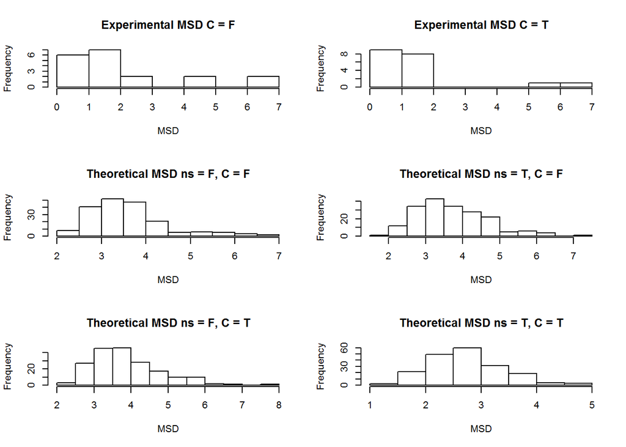

### MSDi

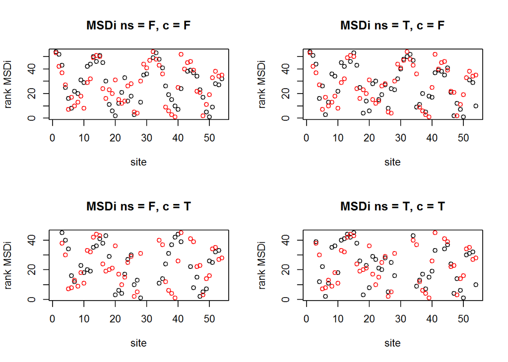

rojo: experimental negro: teorico

Los perfiles de MSDi fueron normalizados con la funcion rank().

### RHO y AUC

Las distribuciones de *auc* y *rho* para cada conjunto se muestran a continuacion (negro = teorico, rojo = experimental)

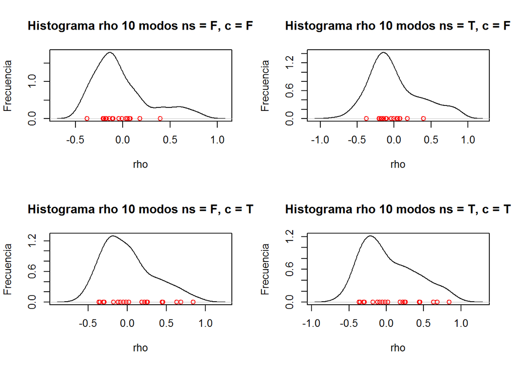

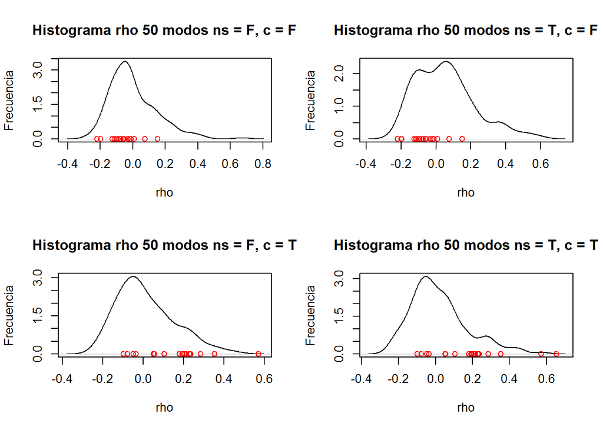

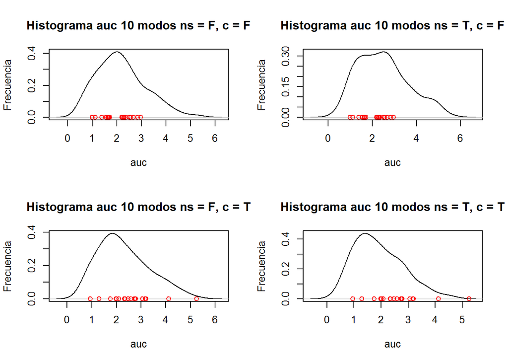

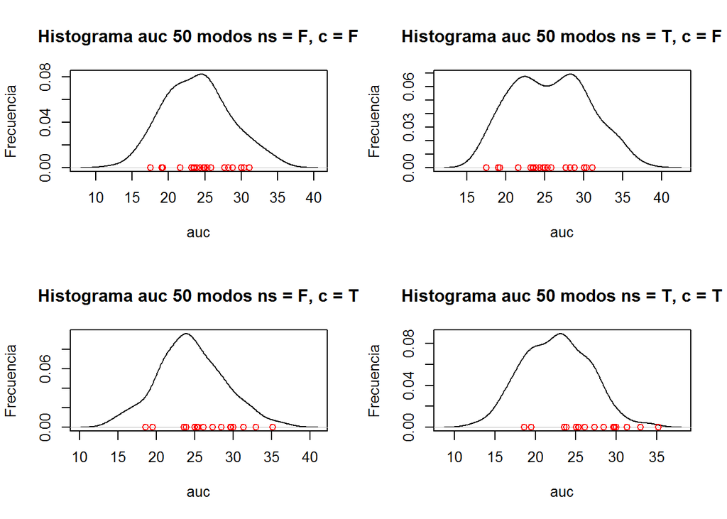

## Pn y Qn

Las distribuciones de *Pn* y *Qn* de los conjuntos son las siguientes:

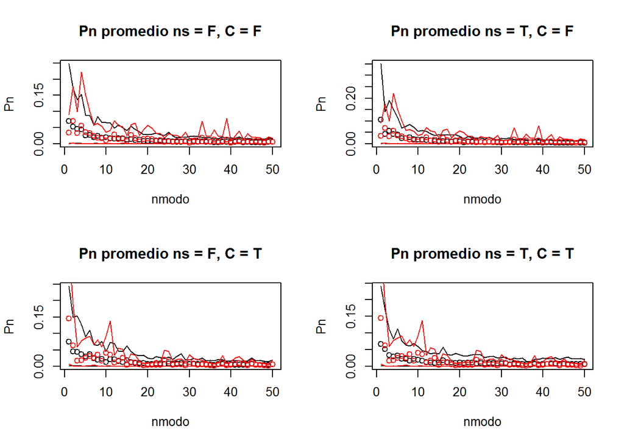

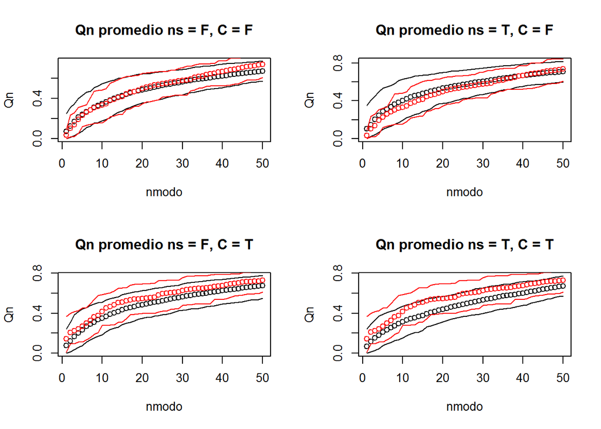

*Negro*: Puntos: promedio de promedios teorico. Lineas: promedio de cuantiles 0.05 y 0.95 de 10 grupos de 19 mutantes teoricas. *Rojo*: Experimental. Puntos: promedio. Lineas: cuantiles 0.05 y 0.95.

## R^2 y MSE

Las comparaciones entre perfines promedio Pn y MSDi teoricos fiteados y experimentales se muestran a continuacion. En cada grafico se muestra la correlacion (R^2) y el error (MSE).

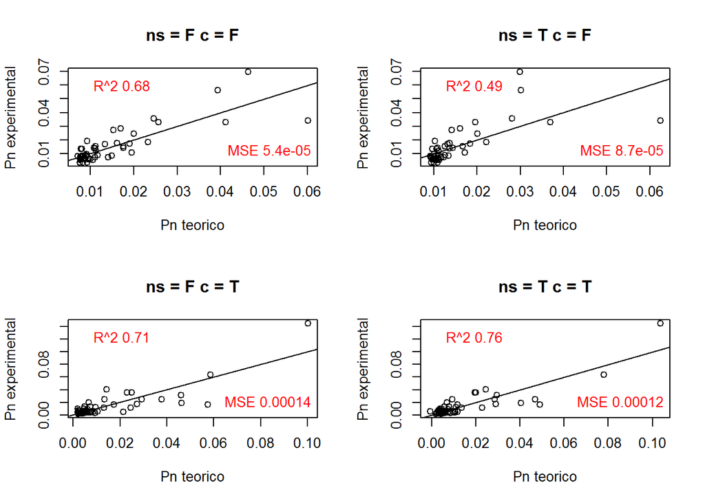

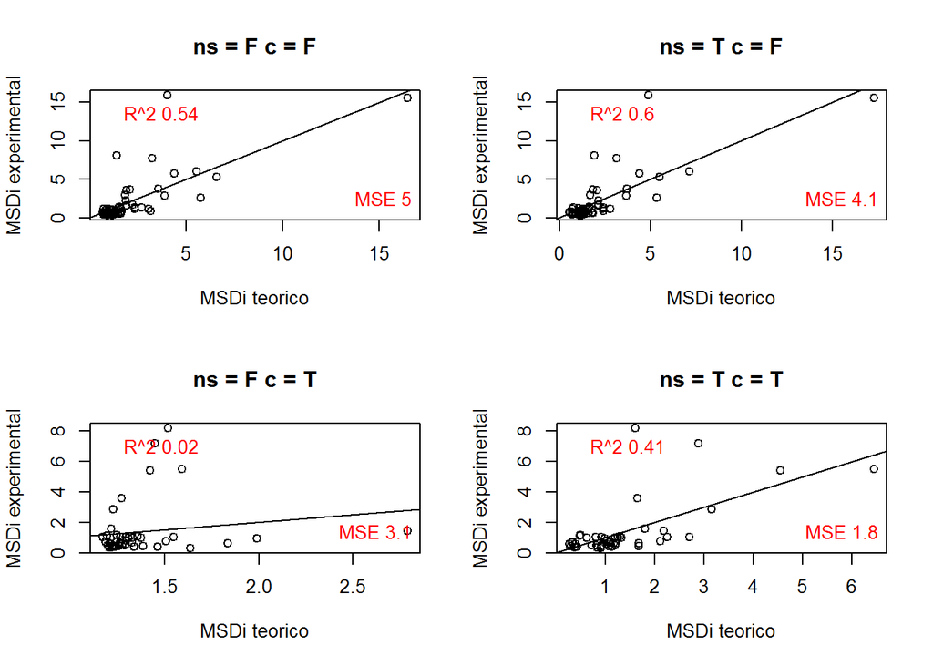